# Chapter 1 Homework

James Livingstone

September 13, 2022

# 1.

1.72 Comparing voltage readings

```r
voltage.csv %>%
  group_by(LOCATION) %>% #control shift m
  descr(VOLTAGE, stats = "common", transpose = T)
```

```
## Descriptive Statistics
## VOLTAGE by LOCATION
## Data Frame: voltage.csv
## N: 30
##
##             Mean   Std.Dev    Min   Median     Max   N.Valid   Pct.Valid
## --------- ------ --------- ------ -------- ------- --------- -----------
##       NEW   9.42      0.48   8.51     9.46   10.12     30.00      100.00
##       OLD   9.80      0.54   8.05     9.98   10.55     30.00      100.00
```

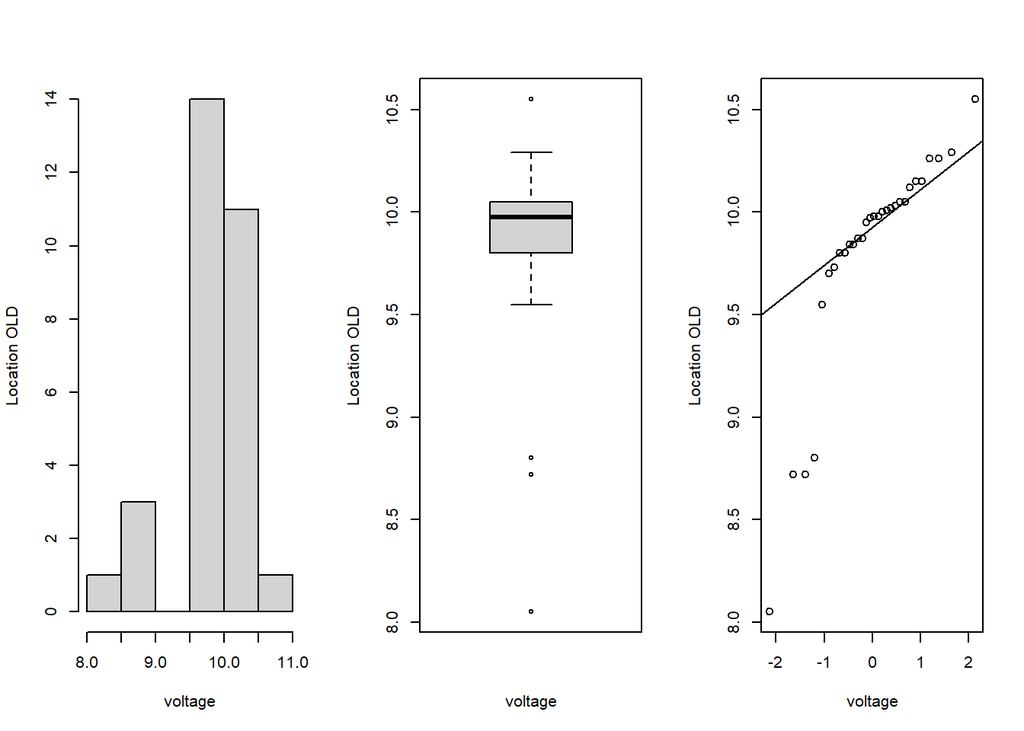

```r
par(mfrow = c(1, 3))
hist(voltage.csv$VOLTAGE[voltage.csv$LOCATION == "OLD"], main = "", xlab = "voltage", ylab = "Location OLD")
boxplot(voltage.csv$VOLTAGE[voltage.csv$LOCATION == "OLD"], main = "", xlab = "voltage", ylab = "Location OLD")
qqnorm(voltage.csv$VOLTAGE[voltage.csv$LOCATION == "OLD"], main = "", xlab = "voltage", ylab = "Location OLD")
qqline(voltage.csv$VOLTAGE[voltage.csv$LOCATION == "OLD"], main = "", xlab = "voltage", ylab = "Location OLD")
```

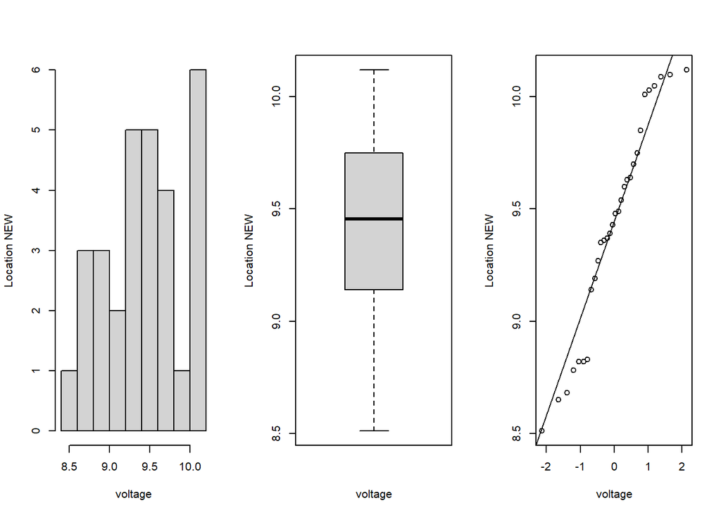

```r
hist(voltage.csv$VOLTAGE[voltage.csv$LOCATION == "NEW"], main = "", xlab = "voltage", ylab = "Location NEW")
boxplot(voltage.csv$VOLTAGE[voltage.csv$LOCATION == "NEW"], main = "", xlab = "voltage", ylab = "Location NEW")
qqnorm(voltage.csv$VOLTAGE[voltage.csv$LOCATION == "NEW"], main = "", xlab = "voltage", ylab = "Location NEW")
qqline(voltage.csv$VOLTAGE[voltage.csv$LOCATION == "NEW"], main = "", xlab = "voltage", ylab = "Location NEW")
```

```r
t.test(VOLTAGE ~ LOCATION, data = voltage.csv, conf.level = 0.90)
```

```
##
##  Welch Two Sample t-test
##
## data:  VOLTAGE by LOCATION
## t = -2.8911, df = 57.16, p-value = 0.005419
## alternative hypothesis: true difference in means between group NEW and group OLD is not equal to 0
## 90 percent confidence interval:
##  -0.6018602 -0.1608065
## sample estimates:
## mean in group NEW mean in group OLD
##          9.422333          9.803667
```

Hypothesis Test Conclusion: There is enough evidence to conclude that there is a significant difference in the mean voltages of old locations and new locations because the confidence interval did not include 0.

2. The old locations depict a mean voltage that is higher than the mean voltage of the new locations. According to the textbook having a higher mean voltage in a location is more suitable for the manufacturing process, with this in mind it would not be of the best strategy to establish the process locally.

# 2.

1.107 Does rudeness really matter in the workplace?

```r
rude.csv %>%
  group_by(Condition) %>% #control shift m
  descr(UsesBrick, stats = "common", transpose = T)
```

```
## Descriptive Statistics
## UsesBrick by Condition
## Data Frame: rude.csv
## N: 53
##
##                  Mean   Std.Dev    Min   Median     Max   N.Valid   Pct.Valid
## ------------- ------- --------- ------ -------- ------- --------- -----------
##       Control   11.81      7.38   0.00    12.00   30.00     53.00      100.00
##          Rude    8.51      3.99   0.00     9.00   18.00     45.00      100.00
```

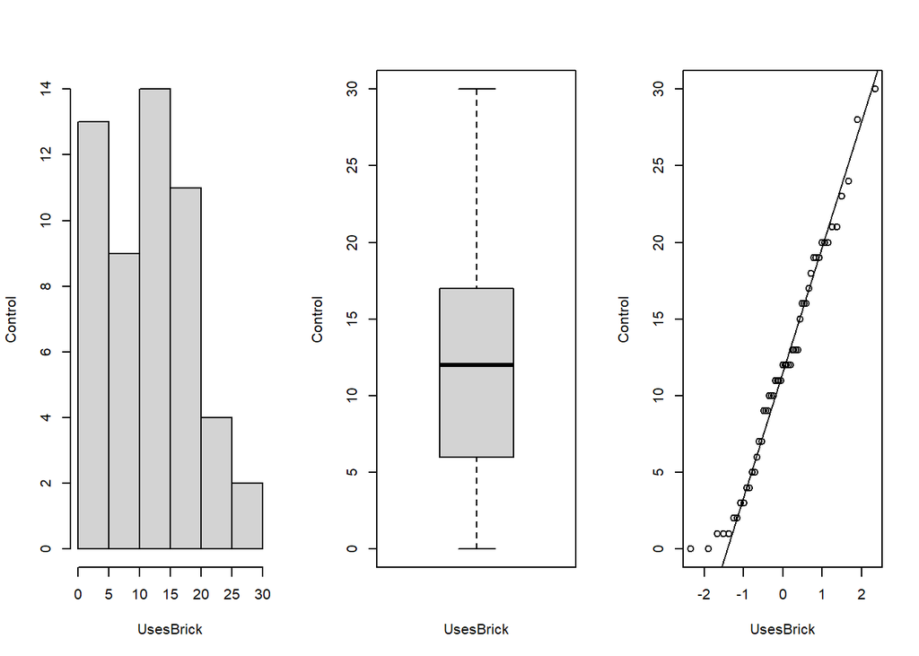

```r
par(mfrow = c(1, 3))
hist(rude.csv$UsesBrick[rude.csv$Condition == "Control"], main = "", xlab = "UsesBrick", ylab = "Control")
boxplot(rude.csv$UsesBrick[rude.csv$Condition == "Control"], main = "", xlab = "UsesBrick", ylab = "Control")
qqnorm(rude.csv$UsesBrick[rude.csv$Condition == "Control"], main = "", xlab = "UsesBrick", ylab = "Control")
qqline(rude.csv$UsesBrick[rude.csv$Condition == "Control"], main = "", xlab = "UsesBrick", ylab = "Control")
```

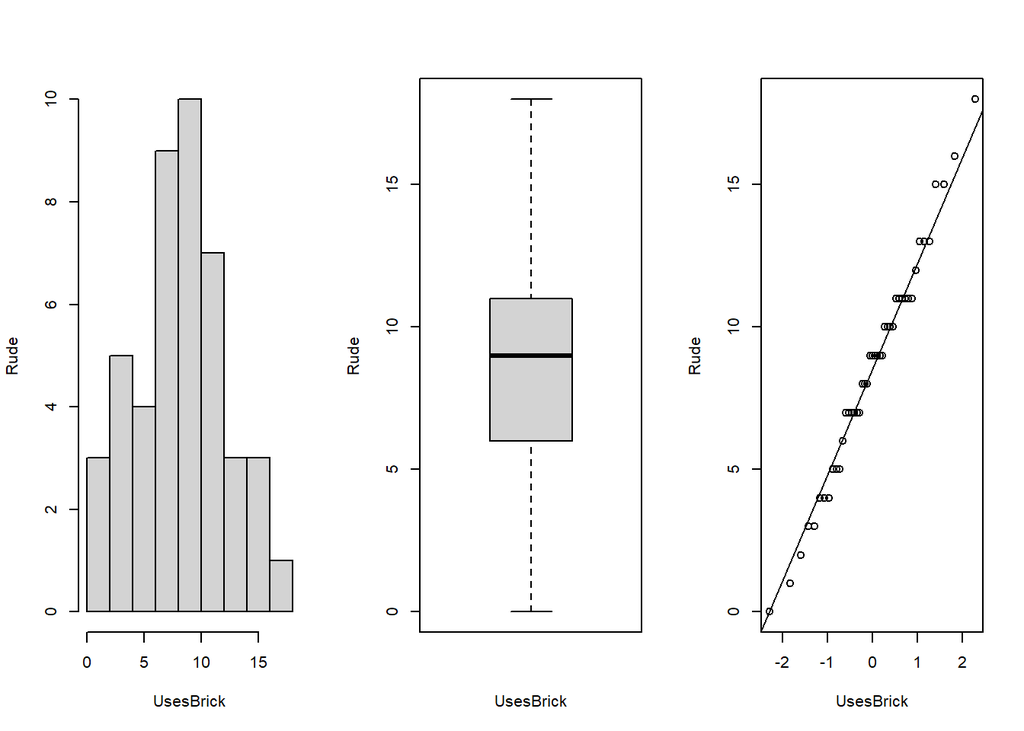

```r
hist(rude.csv$UsesBrick[rude.csv$Condition == "Rude"], main = "", xlab = "UsesBrick", ylab = "Rude")
boxplot(rude.csv$UsesBrick[rude.csv$Condition == "Rude"], main = "", xlab = "UsesBrick", ylab = "Rude")
qqnorm(rude.csv$UsesBrick[rude.csv$Condition == "Rude"], main = "", xlab = "UsesBrick", ylab = "Rude")
qqline(rude.csv$UsesBrick[rude.csv$Condition == "Rude"], main = "", xlab = "UsesBrick", ylab = "Rude")
```

```r
t.test(UsesBrick ~ Condition, data = rude.csv, conf.level = 0.99)
```

```
##
##  Welch Two Sample t-test
##
## data:  UsesBrick by Condition
## t = 2.8068, df = 82.431, p-value = 0.006243
## alternative hypothesis: true difference in means between group Control and group Rude is not equal to 0
## 99 percent confidence interval:
##  0.1998635 6.4005558
## sample estimates:
## mean in group Control    mean in group Rude
##             11.811321              8.511111
```

Hypothesis Test Conclusion: The results of the statistical analysis determined that there is a t-value of 2.81, and a p-value of 0.006, which means we can reject the null hypothesis. This gives us enough evidence to conclude that there is a significant difference in the mean values of the number of uses of the brick between the control group and the rude group. There is sufficient evidence to conclude that the true mean performance level for students in the rudeness condition (8.51) is lower than the true mean performance level for students in the control group (11.81).